# Anatomia di un trasferimento

Un'analisi sui trasferimenti del calciomercato odierno e passato.

# Introduzione e Obiettivi della Ricerca

**Motivazione del Progetto:** Valutare sotto un punto di vista economico il calcio attraverso il suo mercato.

**Domande di Ricerca:**

1. **Analisi del Trend:** qual è l'andamento dei costi dei trasferimenti? E considerando la componente inflattiva?
2. **Impatto con uno shock:** in che modo il mercato reagisce agli shock della vita esterna?

# Descrizione del Dataset

**Fonte e Origine:**

- **Dataset:** Dati estratti dal portale *Transfermarkt*.
- **Copertura Temporale:** Stagioni dal 2010/2011 al 2023/2024.
- **Disponibilità:** [Dataset Kaggle consultabile](https://www.kaggle.com/datasets/davidcariboo/player-scores/data)

**Contenuto dei Dati:** Il dataset include variabili quantitative e categoriche per ogni trasferimento:

- *Transfer Fee* (Costo del cartellino).
- *Market Value* (Valore stimato).
- *Stagione* e *Dati Anagrafici* (Età, Ruolo, Nazionalità).

**Limiti dello Studio:**

- **Ingaggi (Wages):** Il dataset traccia solo costo cartellino, mancano gli stipendi che rappresentano cifre significative.
- **Commissioni:** Non sono inclusi i costi accessori (agenti, premi alla firma), pertanto la spesa analizzata è una stima al ribasso del costo reale.

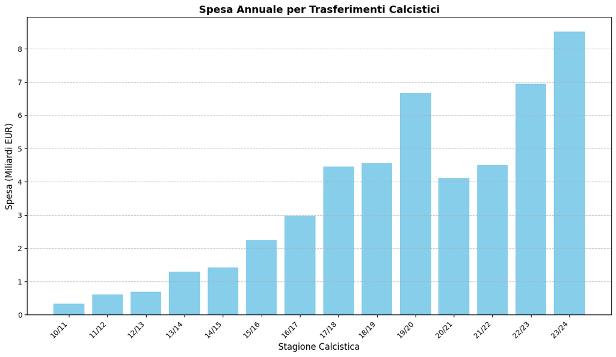

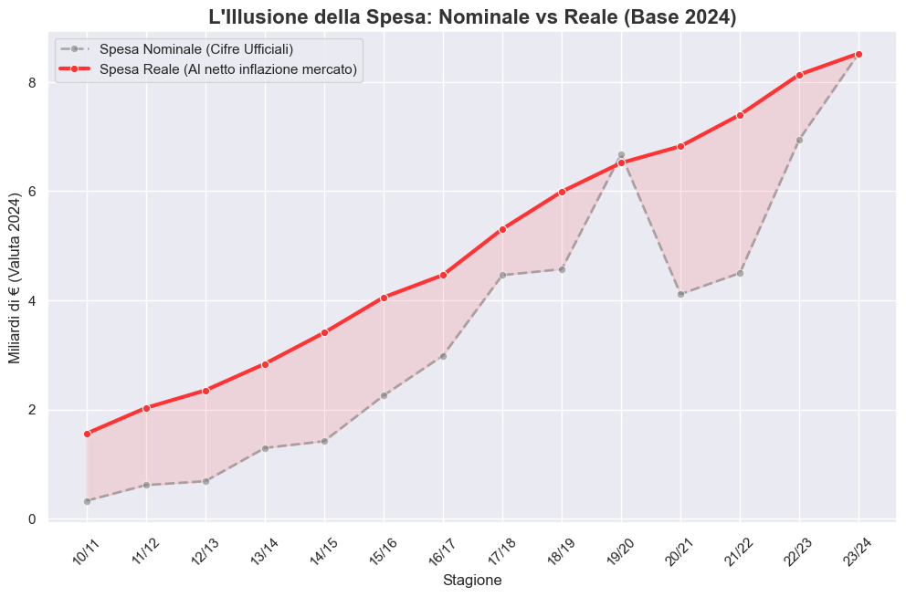

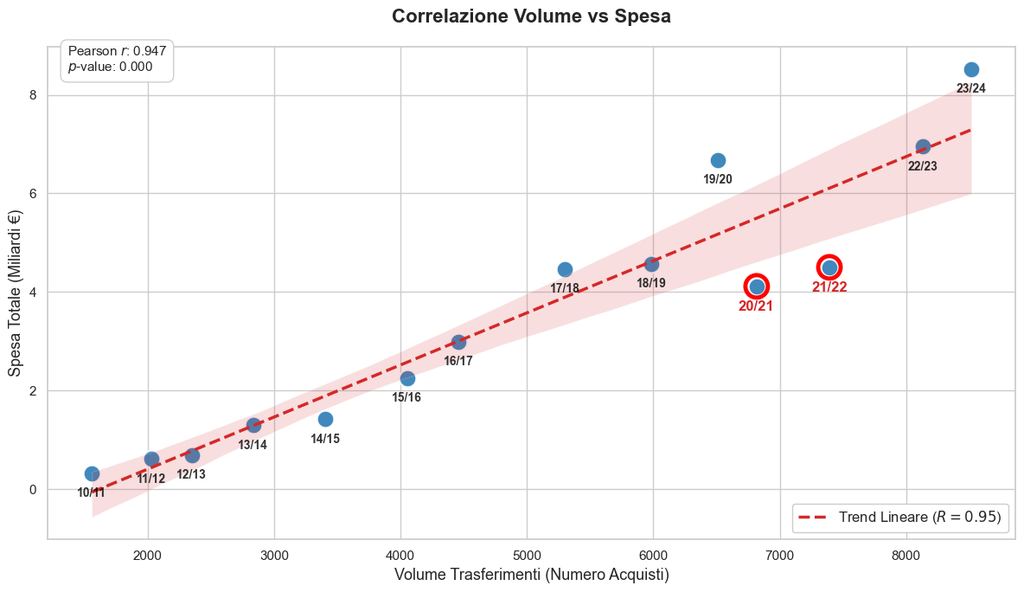

# Conclusioni e Main Findings

**2. Risposta sulla Correlazione (Struttura del Mercato):** Esiste una correlazione lineare molto forte ($r \approx 0.95$) tra numero di acquisti e spesa totale in condizioni normali. Tuttavia, lo studio ha identificato un punto di rottura:

- **L'Anomalia COVID (2020-2022):** In questo periodo la correlazione si indebolisce significativamente. L'alto volume di scambi a fronte di una bassa spesa indica un cambiamento strutturale temporaneo (ricorso a prestiti/scambi) causato dalla crisi di liquidità.

**Sintesi:** Il mercato calcistico mostra una rigidità strutturale (alta correlazione) ma è altamente vulnerabile all'inflazione dei prezzi e agli shock di liquidità esogeni.